# R Notebook

Let’s look at the loadings on the first four PCs:

```r
melted <- full_join(melted, factornames, by = c("Var1"= "Measure_Abb"))
```

```
Column `Var1`/`Measure_Abb` joining factor and character vector, coercing into character vector
```

[figure not shown]

For the first principal component, we see that there is positive loadings for several measures in the Social and Economic Environment factor. They include child poverty, children in single-parent households, and unemployment. This could perhaps be interpreted as growing up poor. Then, the next three heights weights come from adult obesity, STIs, and teen births. Could this be interpreted as risky or non-healthy behavior? The following highest weights are inadequate social support, physical inactivity, housing problems, violent crime, and injury deaths – suggesting unsafe neighborhoods and poor social networks. Finally, the smallest positive weights come from being uninsured, preventable hospital stays, alcohol impaired driving deaths, rinking water violations, and adult smoking. There is a theme, again, of risky behaviors. THe financial aspect may be telling of the inability to account for risky contexts and behaviors.

For the negative weights, being above average in having adequate food, education, preventive behavior, having physicians within distance, exercise opportunities, all point to having better health.

We might name this context, resource-dependent risk behaviors?

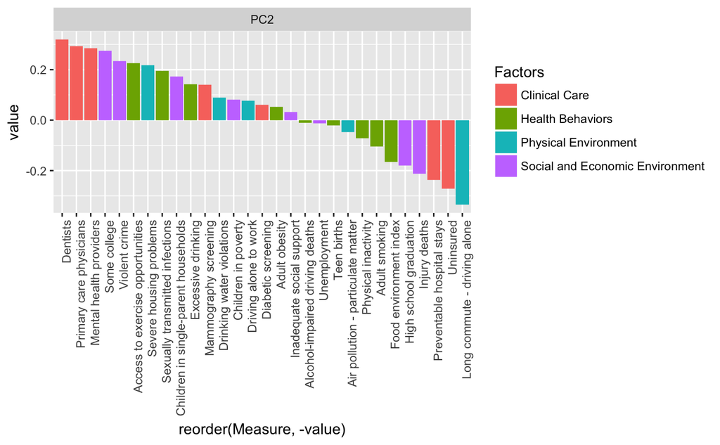

Access to providers, education, crime (?), exercise opportunities, housing issues, STIs, single-parent households, illustrate those who have access to resources but may live in urbn areas? Density of providers and access to things, but high crime, high rates of infection, and single parent house holds. The urban element?

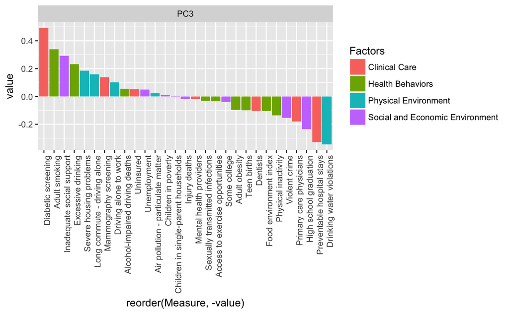

Preventative care.

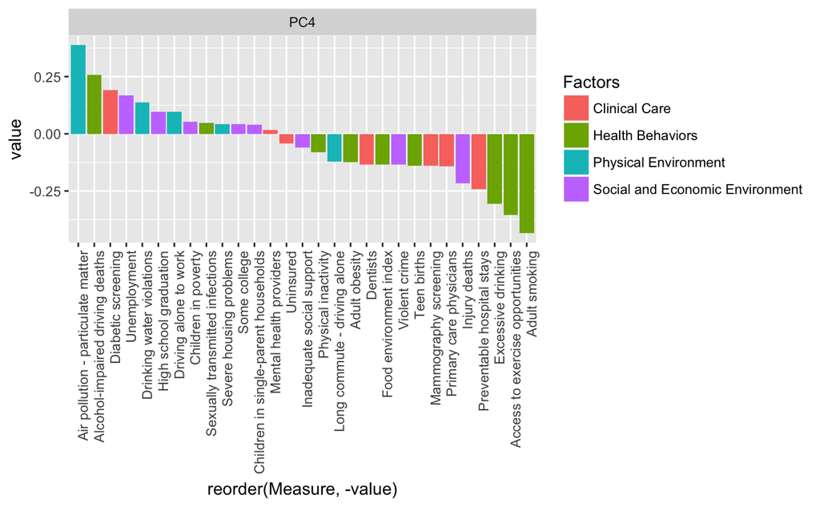

Rural areas.

Weights are constructed with the percent of variance each PC accounts for divided by the total amount o variance the chosen PCs account for.

$$\rho = \frac{0.2725}{0.54748}*Factor_1+\frac{0.1598}{0.54748}*Factor_2+\frac{0.06199}{0.54748}*Factor_3+\frac{0.05325}{0.54748}*Factor_3$$

## Do it all again for Kentucky

```r
varKY <- varKY %>% mutate_all(funs(ifelse(is.na(.), 0, .)))
KY.pca <- prcomp(varKY,
                 center = TRUE,
                 scale. = TRUE)
summary(KY.pca)
```

```
Importance of components%s:
                          PC1    PC2     PC3    PC4     PC5     PC6     PC7     PC8     PC9    PC10
Standard deviation     2.8006 1.9167 1.38983 1.2812 1.22281 1.14961 1.08454 1.00986 1.00824 0.92913
Proportion of Variance 0.2705 0.1267 0.06661 0.0566 0.05156 0.04557 0.04056 0.03517 0.03505 0.02977
Cumulative Proportion  0.2705 0.3972 0.46376 0.5204 0.57192 0.61750 0.65806 0.69322 0.72827 0.75804
                          PC11    PC12    PC13    PC14    PC15    PC16   PC17   PC18    PC19    PC20
Standard deviation     0.81964 0.80972 0.76812 0.74949 0.73002 0.71499 0.6959 0.6439 0.61946 0.57405
Proportion of Variance 0.02317 0.02261 0.02035 0.01937 0.01838 0.01763 0.0167 0.0143 0.01323 0.01136
Cumulative Proportion  0.78121 0.80382 0.82416 0.84353 0.86191 0.87954 0.8962 0.9105 0.92376 0.93513
                          PC21    PC22    PC23    PC24   PC25    PC26    PC27    PC28    PC29
Standard deviation     0.56271 0.54620 0.51504 0.50549 0.4601 0.43344 0.36837 0.34325 0.30410
Proportion of Variance 0.01092 0.01029 0.00915 0.00881 0.0073 0.00648 0.00468 0.00406 0.00319
Cumulative Proportion  0.94605 0.95633 0.96548 0.97429 0.9816 0.98807 0.99275 0.99681 1.00000
```

```r
loadings <- as.data.frame(KY.pca$rotation) #create a data frame of PCA loadings
melted <-  melt(KY.pca$rotation[,1:4])
melted <- full_join(melted, factornames, by = c("Var1"= "Measure_Abb"))
```

```
Column `Var1`/`Measure_Abb` joining factor and character vector, coercing into character vector
```

```r
PC1 <- melted %>% filter(Var2=="PC1") %>% ggplot(aes(x = reorder(Measure,-value),y = value, fill=Factors)) + geom_bar(stat="identity") + facet_wrap(~Var2) + theme(axis.text.x = element_text(angle = 90, hjust = 1))
PC2 <- melted %>% filter(Var2=="PC2") %>% ggplot(aes(x = reorder(Measure,-value),y = value, fill=Factors)) + geom_bar(stat="identity") + facet_wrap(~Var2) + theme(axis.text.x = element_text(angle = 90, hjust = 1))
PC3 <- melted %>% filter(Var2=="PC3") %>% ggplot(aes(x = reorder(Measure,-value),y = value, fill=Factors)) + geom_bar(stat="identity") + facet_wrap(~Var2) + theme(axis.text.x = element_text(angle = 90, hjust = 1))
PC4 <- melted %>% filter(Var2=="PC4") %>% ggplot(aes(x = reorder(Measure,-value),y = value, fill=Factors)) + geom_bar(stat="identity") + facet_wrap(~Var2) + theme(axis.text.x = element_text(angle = 90, hjust = 1))
```

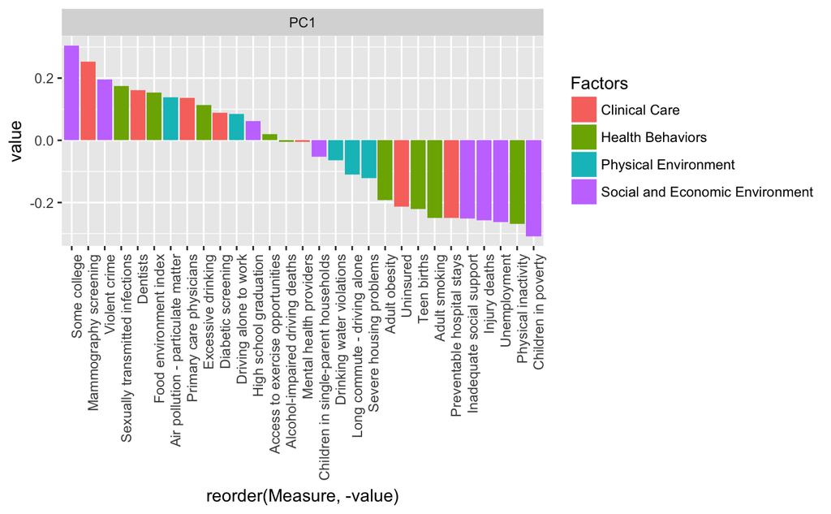

```r
PC2
```

[output not shown]

```r
PC3
```

[output not shown]

```r
PC4
```

[output not shown]

$$\rho = \frac{0.2705}{0.5204}*Factor_1+\frac{0.1267}{0.5204}*Factor_2+\frac{0.06661}{0.5204}*Factor_3+\frac{0.0566}{0.5204}*Factor_3$$